# mashonly

### Compare with MASH

Now we can compare with mash. In this model, for each gene J:

$chat |\mu, V = \mu + \beta + E$

$chat - \mu = \beta + E$

and $E \sim N(0,V)$ while $\beta ~ \sum_{p} \pi_{p} N(0, U_{p})$

```r
rm(list=ls())

library('mashr')
set.seed(123)
c=chat_sim_fsingle_fixedomega(n = 1000,d = 8,omega = 2,esd = 1,reals=1)
saveRDS(c,"chatfixedomega.rds")
diag(c$covmat)
```

```
## [1] 0 0 0 0 0 0 1 1
```

```r
t=c$t;b=c$chat;se=c$shat;R=ncol(t)

#Now wfull will be the median
wfull=t(apply(b,1,function(x){x-median(x)}))
##show that they sum to 0

#plot(rowSums(wfull),ylim=c(-1,1))
```

Now we proceed as in mash, selecting the strongest deviations from the median:

```r
s.j=se/se
v.j=s.j
absmat=abs(t(apply(t,1,function(x){x-median(x)})))
tmedian=(t(apply(t,1,function(x){x-median(x)})))

index=which(rowSums(c$beta)!=0)
sparsestrongt=tmedian[index,]
strongprojectedt=sparsestrongt
```

```r
write.table(sparsestrongt,"sparsestrongt.txt",col.names = FALSE,row.names=FALSE)
```

Now, we need to project into the centered space to estimate the covariance matrix of the true deviations, using the full L since $v$ will be R, and not $R-1$.

```r
system('/Users/sarahurbut/miniconda3/bin/sfa -gen sparsestrongt.txt -g 789 -k 5 -n 8 i -o sparseFmediancentered')
A="sparseFmediancentered"

factor.mat=as.matrix(read.table("sparseFmediancentered_F.out"))
lambda.mat=as.matrix(read.table("sparseFmediancentered_lambda.out"))

library("ExtremeDeconvolution")
t.stat=strongprojectedt
w=wfull
R=ncol(t.stat)
K=3; P=3
init.cov=init.covmat(t.stat=t.stat,factor.mat = factor.mat,lambda.mat = lambda.mat,K=K,P=P)
init.cov.list=list()
for(i in 1:K){init.cov.list[[i]]=init.cov[i,,]}
head(init.cov.list)
```

```
## [[1]]
##              [,1]        [,2]         [,3]        [,4]        [,5]
## [1,]  1.005420277 -0.05597104  0.009924314 -0.02874188  0.03255654
## [2,] -0.055971037  0.94492986 -0.051730889 -0.07264815 -0.04392898
## [3,]  0.009924314 -0.05173089  0.946175117 -0.00252679 -0.04945855
## [4,] -0.028741883 -0.07264815 -0.002526790  0.92364723 -0.02553899
## [5,]  0.032556543 -0.04392898 -0.049458546 -0.02553899  0.98152590
## [6,] -0.005281466 -0.01919895 -0.046583948  0.02074904 -0.03110443
## [7,] -0.372349424 -0.29782948 -0.303327524 -0.32727302 -0.33250874
## [8,] -0.391313947 -0.28797578 -0.290110307 -0.29789828 -0.33535391
##              [,6]       [,7]       [,8]
## [1,] -0.005281466 -0.3723494 -0.3913139
## [2,] -0.019198950 -0.2978295 -0.2879758
## [3,] -0.046583948 -0.3033275 -0.2901103
## [4,]  0.020749037 -0.3272730 -0.2978983
```

[output cut: 44 more lines]

```r
mean.mat=matrix(rep(0,ncol(t.stat)*nrow(t.stat)),ncol=ncol(t.stat),nrow=nrow(t.stat))

ydata=  t.stat
xamp= rep(1/K,K)
xcovar= init.cov.list
fixmean= TRUE
ycovar=  v.j
xmean=   mean.mat
projection= list();for(l in 1:nrow(t.stat)){projection[[l]]=diag(1,R)}

e=extreme_deconvolution(ydata=ydata,ycovar=ycovar,xamp=xamp,xmean=xmean,xcovar=init.cov.list,fixmean=T,projection=projection)

max.step=deconvolution.em.with.bovy(t.stat = strongprojectedt,factor.mat = factor.mat,v.j = s.j,lambda.mat = lambda.mat,K = 3,P = 3 )

##Show how the ranks is preserved
apply(max.step$true.covs,1,function(x){qr(x)$rank})
```

```
## [1] 8 5 3
```

```r
A="sparseoldmash"

covmash=compute.hm.mash.covmat.all.max.step.fixed.omega(omega = 2,Q = 5,lambda.mat = lambda.mat,factor.mat = factor.mat,max.step = max.step,zero = TRUE,power = 2,A,bma = TRUE)$cov

sapply(covmash,max)
```

```
##  [1] 2 2 2 2 2 2 2 2 2 2 2 2 2 2 2 2 2 2 0
```

```r
##Show how the ranks is preserved
apply(max.step$true.covs,1,function(x){qr(x)$rank})
```

```
## [1] 8 5 3
```

```r
all.equal(covmash[[2]]/max(diag(covmash[[2]])),max.step$true.covs[1,,]/max(diag(max.step$true.covs[1,,])))
```

```
## [1] TRUE
```

```r
all.equal(covmash[[3]]/max(diag(covmash[[3]])),max.step$true.covs[3,,]/max(diag(max.step$true.covs[3,,])))
```

```
## [1] TRUE
```

```r
all.equal(covmash[[9]]/max(diag(covmash[[9]])),max.step$true.covs[2,,]/max(diag(max.step$true.covs[2,,])))
```

```
## [1] TRUE
```

```r
length(covmash)
```

```
## [1] 19
```

```r
#
#
# covmash=compute.hm.covmat.all.max.step(max.step = max.step,b.hat = wfull,se.hat = se,t.stat = strongprojectedt,Q = 5,lambda.mat = lambda.mat,A = "sparseoldmash",factor.mat = factor.mat,zero = T,power = 2)$covmat
#
# all.equal(covmash[[2]]/max(diag(covmash[[2]])),max.step$true.covs[1,,]/max(diag(max.step$true.covs[1,,])))
# all.equal(covmash[[3]]/max(diag(covmash[[3]])),max.step$true.covs[3,,]/max(diag(max.step$true.covs[3,,])))
# all.equal(covmash[[9]]/max(diag(covmash[[9]])),max.step$true.covs[2,,]/max(diag(max.step$true.covs[2,,])))
```

Now, proceed as always, estimating likelihood and computing posteriors.

```r
A="sparseoldmash"
compute.hm.train.log.lik.pen(train.b = wfull,se.train = se,covmat = covmash,A=A,pen=1)
```

```r
pis=readRDS(paste0("pis",A,".rds"))$pihat

weightedquants=lapply(seq(1:nrow(wfull)),function(j){total.quant.per.snp(j,covmash,b.gp.hat=wfull,se.gp.hat = se,pis,A=A,checkpoint = FALSE)})
```

Let’s look at the ‘learned’ covariance matrix of each as well as the true covariance matrices of each, and see how they comapre to the true configurations. Recall that the true configurations looked like this:

```r
c=readRDS("chatfixedomega.rds")
diag(c$covmat)
```

```
## [1] 0 0 0 0 0 0 1 1
```

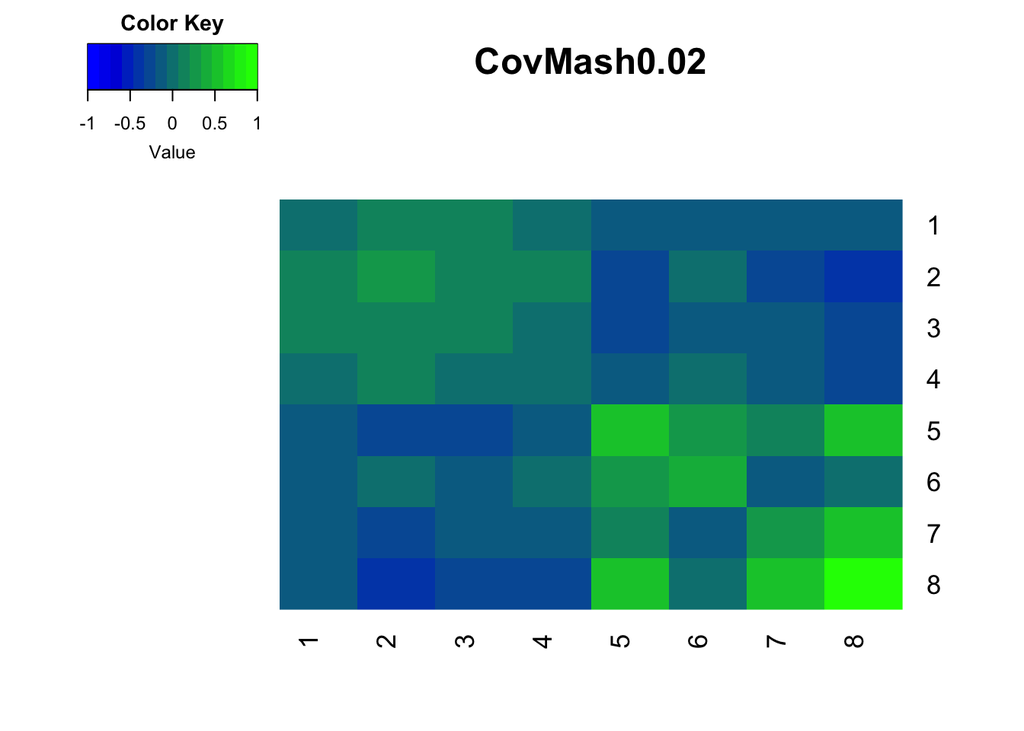

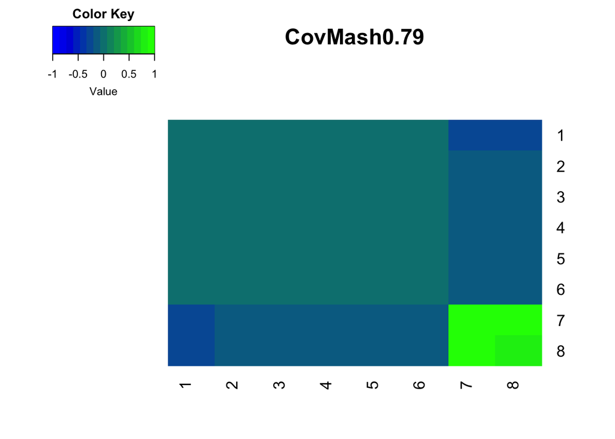

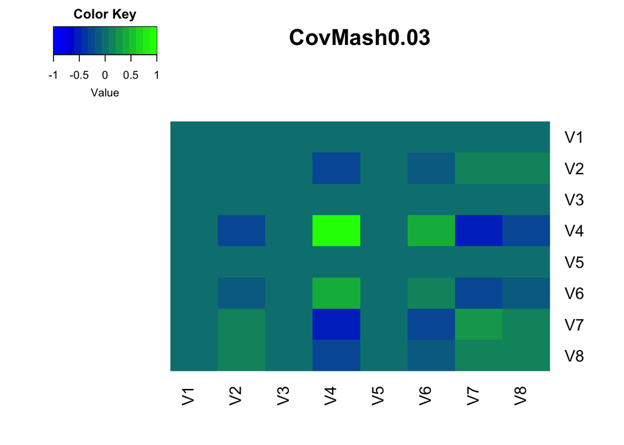

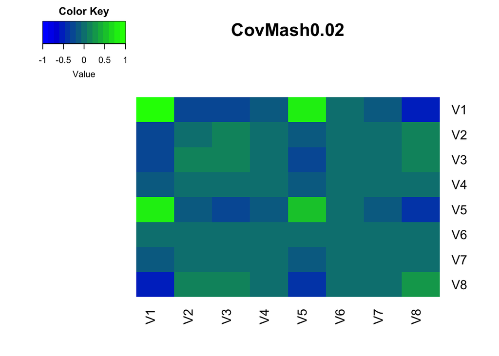

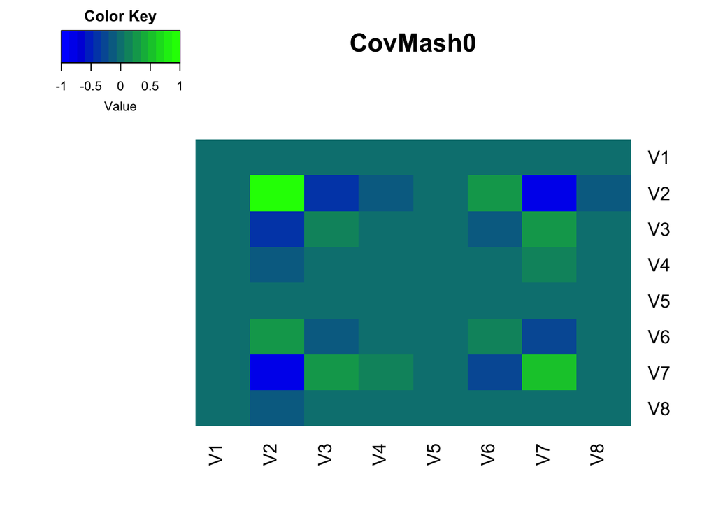

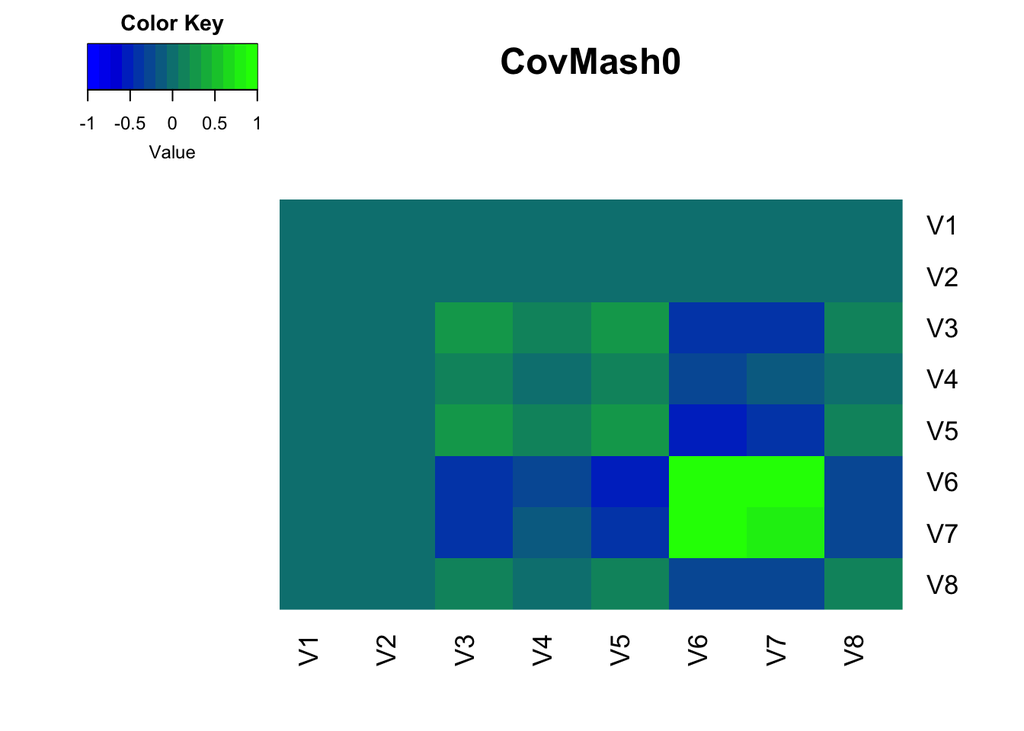

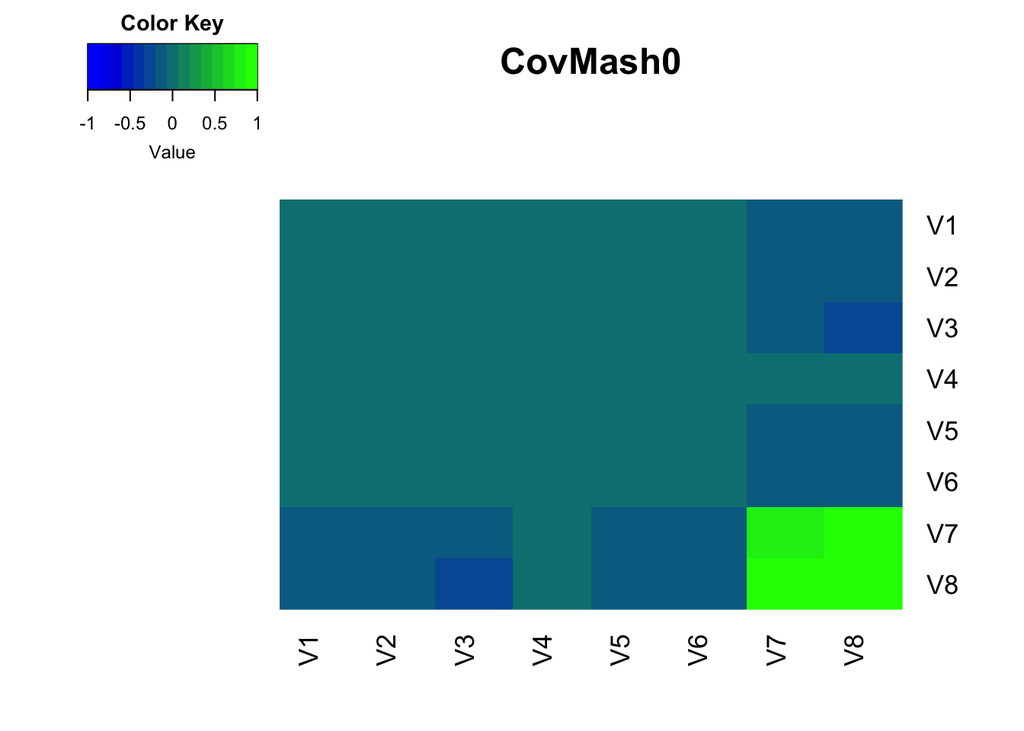

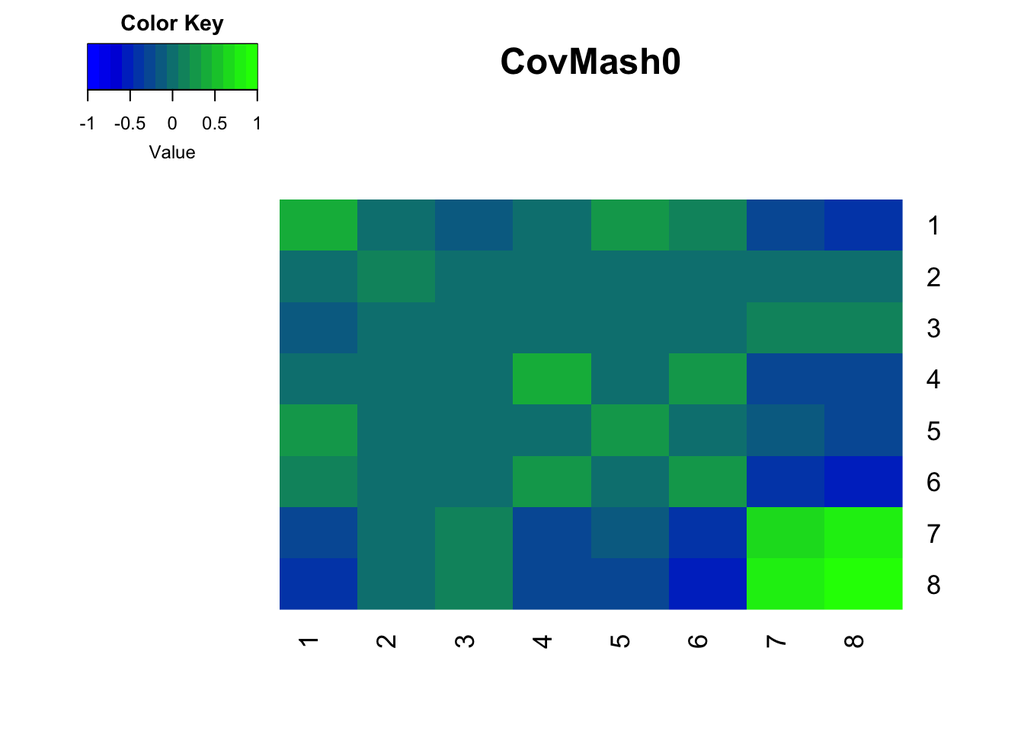

```r
pis=readRDS("pissparseoldmash.rds")$pihat
pi.mat.old.mash=matrix(pis[-length(pis)],ncol=18,byrow=TRUE)
covmash=readRDS("covmatsparseoldmash.rds")

library('gplots')
library('colorRamps')

for(i in 2:9){
  x=covmash[[i]]
  heatmap.2(x/max(diag(x)),Rowv = NULL,Colv = NULL,dendrogram = "none",col=blue2green,density.info = "none",trace="none",main=paste0("CovMash",round(colSums(pi.mat.old.mash)[i],2)))}
```

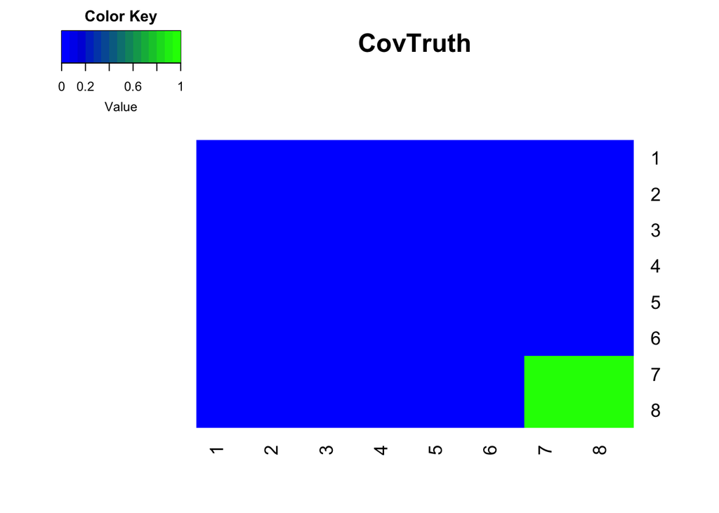

```r
x=c$covmat
heatmap.2(x/max(diag(x)),Rowv = NULL,Colv = NULL,dendrogram = "none",col=blue2green,density.info = "none",trace="none",main="CovTruth")
```

Test to show our calculations are accurate:

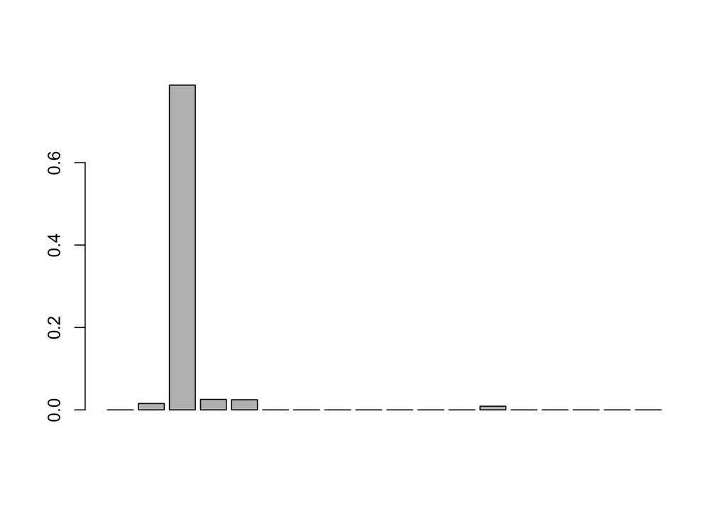

```r
mash.means=as.matrix(read.table("sparseoldmashposterior.means.txt")[,-1])
lfsr.mash=as.matrix(read.table("sparseoldmashlfsr.txt"))[,-1]
cov=readRDS("covmatsparseoldmash.rds")
pis=readRDS("pissparseoldmash.rds")$pihat
pi.mat.old.mash=matrix(pis[-length(pis)],ncol=18,byrow=TRUE)
#pisnobase=readRDS("pissparseLwithED.rds")$pihat
#pi.mat.nobase=matrix(pisnobase[-length(pisnobase)],ncol=18,byrow=TRUE)
barplot(colSums(pi.mat.old.mash))
```

```r
#barplot(colSums(pi.mat.nobase))

w=data.frame(wfull)
R=ncol(w)
j=10

arrays=post.array.per.snp.no.baseline(j = 10,covmat = cov,b.gp.hat = w,se.gp.hat = se,L = diag(1,R))
mash.arrays=post.array.per.snp(j = 10,covmat = cov,b.gp.hat = w,se.gp.hat = se)
##show same algebra


k=5

V.gp.hat=diag(se[j,])^2

b.mle = as.vector(w[j,])

lapply(seq(1:5),function(x){all.equal(arrays[[x]],mash.arrays[[x]])})
```

```
## [[1]]
## [1] TRUE
##
## [[2]]
## [1] TRUE
##
## [[3]]
## [1] TRUE
##
## [[4]]
## [1] TRUE
##
## [[5]]
## [1] TRUE
```

```r
L=diag(1,R)
LSigL=L%*%cov[[k]]%*%t(L)
LVL=L%*%V.gp.hat%*%t(L)

LSigL_list=lapply(cov,function(x){L%*%x%*%t(L)})
identical(LSigL_list[[k]],LSigL)
```

```
## [1] TRUE
```

```r
identical(as.numeric(arrays$post.means[k,]),as.numeric(post.mean.with.proj(b.mle = t(b.mle),tinv = solve(LVL+L%*%cov[[k]]%*%t(L)),U.k = cov[[k]],L = L)))
```

```
## [1] TRUE
```

```r
identical(as.numeric(arrays$post.covs[k,]),as.numeric(diag(post.cov.with.proj(tinv = solve(LVL+L%*%cov[[k]]%*%t(L)),U.k = cov[[k]],L = L))))
```

```
## [1] TRUE
```

```r
b.mle=as.vector(t(w[j,]))##turn i into a R x 1 vector
V.gp.hat=diag(se[j,])^2
V.gp.hat.inv <- solve(V.gp.hat)
U.gp1kl= (post.b.gpkl.cov(V.gp.hat.inv, cov[[k]]))

identical(as.numeric(mash.arrays$post.means[k,]),as.numeric(post.b.gpkl.mean(b.mle = b.mle,V.gp.hat.inv = V.gp.hat.inv,U.gp1kl = U.gp1kl)))
```

```
## [1] TRUE
```

```r
identical(as.numeric(mash.arrays$post.covs[k,]),as.numeric(diag(U.gp1kl)))
```

```
## [1] TRUE
```

```r
log.lik.snp=log.lik.func(b.mle,LVL,LSigL_list)
log.lik.minus.max=log.lik.snp-max(log.lik.snp)
exp.vec=exp(log.lik.minus.max)
post.weights=t(exp.vec*pis/sum(exp.vec*pis))

all.equal(as.numeric(post.weights%*%arrays$post.means),as.numeric(mash.means[j,]))
```

```
## [1] TRUE
```

Compare RMSE:

```r
mle=as.matrix(wfull)
beta=as.matrix(c$beta)

mash.means=as.matrix(read.table("sparseoldmashposterior.means.txt")[,-1])

standard=sqrt(mean((beta-mle)^2))
sqrt(mean((mash.means-beta)^2))/standard
```

```
## [1] 0.4283506
```

```r
#sqrt(mean((mash.nobaselinemeans-beta)^2))/standard
```

## Comparing with truth.

Now, let’s try this with the true prior. Here, we use the covariance matrices that were used to simulate the data as the output of *c$covmat*

```r
rm(list=ls())
library('mash')
c=readRDS("chatfixedomega.rds")
diag(c$covmat)
```

```
## [1] 0 0 0 0 0 0 1 1
```

```r
t=c$t;b=c$chat;se=c$shat
covl=list(2*c$covmat)
#hist(t)
#hist(b)
R=ncol(t)
L=diag(R)-1/R*as.vector(rep(1,R))%*%t(as.vector(rep(1,R)))
wfull=t(L%*%t(b))
sjmat=convertstandarderrors(s.j = se,L=L)##make this be the standard errors of all, it is
A="withfixedomega"
#covs=compute.covmat.using.truth.fixed.omega(covlist = covl,A = "withfixedomega",omega = 2,zero = TRUE)
#length(covs)
#barplot(diag(covs[[2]]/max(diag(covs[[2]]))))
covs=covl
w=data.frame(wfull)[,-1]
```

```r
A="withfixedomegamnb"
compute.hm.train.log.lik.pen.with.L(w,se.train = se,covmat = covs,A = A,pen = 1,L = L[-1,])
```

```r
#pis=readRDS(paste0("pis",A,".rds"))$pihat
pis=1

likmat=t(readRDS(paste0("liketrain",A,".rds")))
test=exp(likmat)
sum(log(test%*%pis))
```

```
## [1] -9556.766
```

```r
for(j in 1:nrow(w)){
total.quant.per.snp.no.baseline(j = j,covmat = covs,b.gp.hat = w,se.gp.hat = se,pis = pis,A = A,checkpoint = F,L = L[-1,])}
```

## Test to show our calculations are accurate:

```r
mash.means=as.matrix(read.table("withfixedomegamnbposterior.means.txt")[,-1])
lfsr.mash=as.matrix(read.table("withfixedomegamnblfsr.txt"))[,-1]
edcov=covl
j=10
arrays=post.array.per.snp.no.baseline(j = 10,covmat = edcov,b.gp.hat = w,se.gp.hat = se,L = L[-1,])
k=1

V.gp.hat=diag(se[j,])^2

b.mle = as.vector(w[j,])

LSigL=L[-1,]%*%edcov[[k]]%*%t(L[-1,])
LVL=L[-1,]%*%V.gp.hat%*%t(L[-1,])

LSigL_list=lapply(edcov,function(x){L[-1,]%*%x%*%t(L[-1,])})
identical(LSigL_list[[k]],LSigL)
```

```
## [1] TRUE
```

```r
identical(as.numeric(arrays$post.means[k,]),as.numeric(post.mean.with.proj(b.mle = t(b.mle),tinv = solve(LVL+L[-1,]%*%edcov[[k]]%*%t(L[-1,])),U.k = edcov[[k]],L = L[-1,])))
```

```
## [1] TRUE
```

```r
identical(as.numeric(arrays$post.covs[k,]),as.numeric(diag(post.cov.with.proj(tinv = solve(LVL+L[-1,]%*%edcov[[k]]%*%t(L[-1,])),U.k = edcov[[k]],L = L[-1,]))))
```

```
## [1] TRUE
```

```r
log.lik.snp=log.lik.func(b.mle,LVL,LSigL_list)
log.lik.minus.max=log.lik.snp-max(log.lik.snp)
#pis=readRDS("piswithfixedomegamnb.rds")$pihat
pis=1
exp.vec=exp(log.lik.minus.max)
post.weights=t(exp.vec*pis/sum(exp.vec*pis))

all.equal(as.numeric(post.weights%*%arrays$post.means),as.numeric(mash.means[j,]))
```

```
## [1] TRUE
```

And let’s also do this with the mash framework:

```r
rm(list=ls())
c=readRDS("chatfixedomega.rds")
covl=list(2*c$covmat)
t=c$t;b=c$chat;se=c$shat

R=ncol(t)
L=diag(R)-1/R*as.vector(rep(1,R))%*%t(as.vector(rep(1,R)))
wfull=t(L%*%t(b))
sjmat=convertstandarderrors(s.j = se,L=L)##make this be the standard errors of all, it is
#covs=compute.covmat.using.truth(b.gp.hat = wfull,sebetahat = sjmat,A="test",zero=TRUE,covlist=covl,power=2)
covs=covl
```

```r
A="mashtruthwithfixedomega"
covs=covl
compute.hm.train.log.lik.pen(train.b = wfull,se.train = se,covmat = covs,A=A,pen=1)
```

```r
pis=readRDS(paste0("pis",A,".rds"))$pihat

pis=1


weightedquants=lapply(seq(1:nrow(wfull)),function(j){total.quant.per.snp(j,covs,b.gp.hat=wfull,se.gp.hat = se,pis,A=A,checkpoint = FALSE)})
```

And test to see if calculations are accurate:

```r
#cov=readRDS("covmatwithfixedomega.rds")
cov=covl
mash.means=as.matrix(read.table("mashtruthwithfixedomegaposterior.means.txt")[,-1])
w=data.frame(wfull)
R=ncol(w)
j=10

arrays=post.array.per.snp.no.baseline(j = 10,covmat = cov,b.gp.hat = w,se.gp.hat = se,L = diag(1,R))
mash.arrays=post.array.per.snp(j = 10,covmat = cov,b.gp.hat = w,se.gp.hat = se)
##show same algebra


k=1

V.gp.hat=diag(se[j,])^2

b.mle = as.vector(w[j,])

lapply(seq(1:5),function(x){all.equal(arrays[[x]],mash.arrays[[x]])})
```

```
## [[1]]
## [1] TRUE
##
## [[2]]
## [1] TRUE
##
## [[3]]
## [1] TRUE
##
## [[4]]
## [1] TRUE
##
## [[5]]
## [1] TRUE
```

```r
L=diag(1,R)
LSigL=L%*%cov[[k]]%*%t(L)
LVL=L%*%V.gp.hat%*%t(L)

LSigL_list=lapply(cov,function(x){L%*%x%*%t(L)})
identical(LSigL_list[[k]],LSigL)
```

```
## [1] TRUE
```

```r
identical(as.numeric(arrays$post.means[k,]),as.numeric(post.mean.with.proj(b.mle = t(b.mle),tinv = solve(LVL+L%*%cov[[k]]%*%t(L)),U.k = cov[[k]],L = L)))
```

```
## [1] TRUE
```

```r
identical(as.numeric(arrays$post.covs[k,]),as.numeric(diag(post.cov.with.proj(tinv = solve(LVL+L%*%cov[[k]]%*%t(L)),U.k = cov[[k]],L = L))))
```

```
## [1] TRUE
```

```r
b.mle=as.vector(t(w[j,]))##turn i into a R x 1 vector
V.gp.hat=diag(se[j,])^2
V.gp.hat.inv <- solve(V.gp.hat)
U.gp1kl= (post.b.gpkl.cov(V.gp.hat.inv, cov[[k]]))

identical(as.numeric(mash.arrays$post.means[k,]),as.numeric(post.b.gpkl.mean(b.mle = b.mle,V.gp.hat.inv = V.gp.hat.inv,U.gp1kl = U.gp1kl)))
```

```
## [1] TRUE
```

```r
identical(as.numeric(mash.arrays$post.covs[k,]),as.numeric(diag(U.gp1kl)))
```

```
## [1] TRUE
```

```r
#pis=readRDS("pismashtruthwithfixedomega.rds")$pihat
pis=1
log.lik.snp=log.lik.func(b.mle,LVL,LSigL_list)
log.lik.minus.max=log.lik.snp-max(log.lik.snp)
exp.vec=exp(log.lik.minus.max)
post.weights=t(exp.vec*pis/sum(exp.vec*pis))

all.equal(as.numeric(post.weights%*%arrays$post.means),as.numeric(mash.means[j,]))
```

```
## [1] TRUE
```

```r
mashnobase.means=as.matrix(read.table("withfixedomegamnbposterior.means.txt")[,-1])

beta=as.matrix(c$beta)
mle=as.matrix(wfull)
mash.means=as.matrix(mash.means)
standard=sqrt(mean((beta-mle)^2))
sqrt(mean((mash.means-beta)^2))/standard
```

```
## [1] 0.3762791
```

```r
sqrt(mean((mashnobase.means-beta)^2))/standard
```

```
## [1] 0.3595063
```

Let’s do the same thing comparing the pis using mash from the truth and from mashnobaseline:

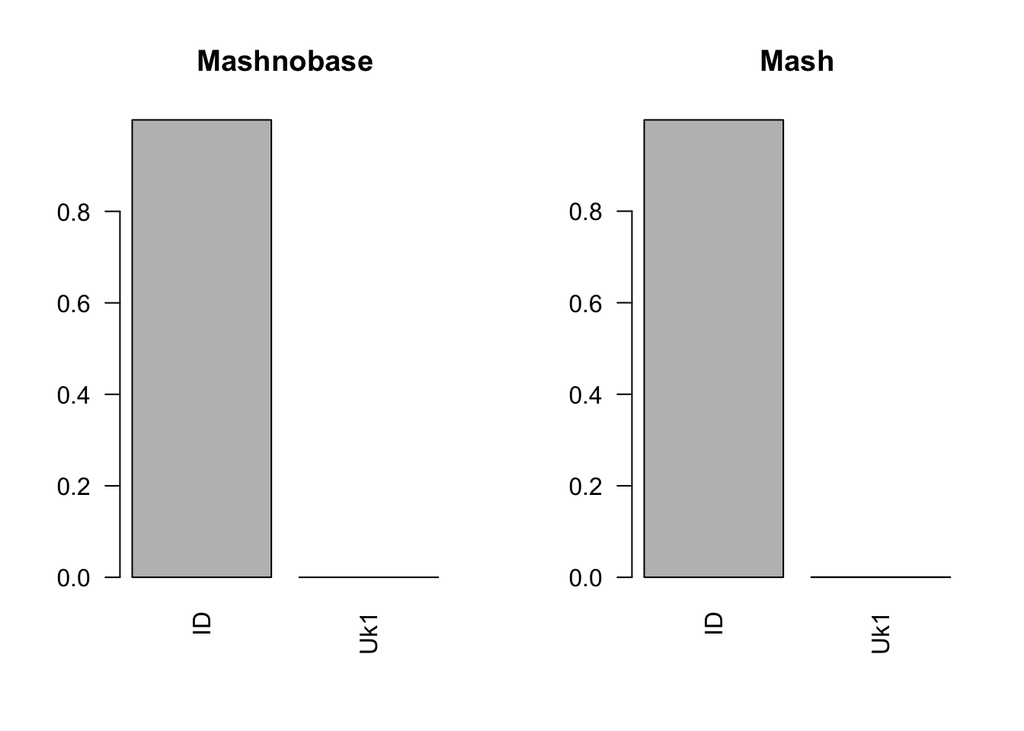

```r
pimash=readRDS("pismashtruthwithfixedomega.rds")$pihat
pied=readRDS("piswithfixedomegamnb.rds")$pihat
par(mfrow=c(1,2))
barplot(colSums(matrix(pied[-length(pied)],ncol=2,byrow=TRUE)),names=c("ID","Uk1"),las=2,main="Mashnobase")
barplot(colSums(matrix(pimash[-length(pied)],ncol=2,byrow=TRUE)),names=c("ID","Uk1"),las=2,main="Mash")
```

$w_{j,R} ~ N(0,V+U)$ $w_{j,R-1} ~ N(0,LVL' + LUL')$ where L is the R-1 x R centering matrix.

In both:

$c = \mu + \beta$ $chat = c + E$ $v \sim \sum_p N(0,Uk)$ $E \sim N(0,V)$

```r
covmash=readRDS("covmatsparseoldmash.rds")
(covmash[[3]]-min(abs(covmash[[3]])))/max(diag(covmash[[3]]))
```

```
##              [,1]          [,2]         [,3]         [,4]         [,5]
## [1,]  0.028044166  0.0053704095  0.016877308  0.013940641  0.018370572
## [2,]  0.005370409  0.0007203226  0.001996587  0.003202894  0.000000000
## [3,]  0.016877308  0.0019965872  0.013038170  0.009391204  0.008405380
## [4,]  0.013940641  0.0032028938  0.009391204  0.008354298  0.006630917
## [5,]  0.018370572  0.0000000000  0.008405380  0.006630917  0.010606663
## [6,]  0.011489134  0.0054098993  0.004268631  0.007361103  0.005762515
## [7,] -0.251797033 -0.1849050561 -0.220564421 -0.214233836 -0.212132987
## [8,] -0.230329600 -0.1697272081 -0.196782845 -0.194250014 -0.195637597
##              [,6]       [,7]       [,8]
## [1,]  0.011489134 -0.2517970 -0.2303296
## [2,]  0.005409899 -0.1849051 -0.1697272
## [3,]  0.004268631 -0.2205644 -0.1967828
## [4,]  0.007361103 -0.2142338 -0.1942500
## [5,]  0.005762515 -0.2121330 -0.1956376
## [6,]  0.013241641 -0.2093122 -0.1958591
## [7,] -0.209312158  0.9729904  0.8705456
## [8,] -0.195859082  0.8705456  0.7856662
```

```r
(covmash[[9]]-min(abs(covmash[[9]])))/max(diag(covmash[[9]]))
```

```
##             [,1]        [,2]        [,3]        [,4]        [,5]
## [1,]  0.34945929 -0.03003910 -0.08330207 -0.02885831  0.25201011
## [2,] -0.03003910  0.09768413 -0.05261209 -0.06096937 -0.03638468
## [3,] -0.08330207 -0.05261209  0.02462917  0.00707250 -0.05491702
## [4,] -0.02885831 -0.06096937  0.00707250  0.32197941 -0.04049156
## [5,]  0.25201011 -0.03638468 -0.05491702 -0.04049156  0.19193898
## [6,]  0.08339145  0.03761377 -0.06647632  0.22995087  0.01421065
## [7,] -0.30511772 -0.04674042  0.06499786 -0.30947162 -0.20339995
## [8,] -0.46633227 -0.02355138  0.10094302 -0.31397793 -0.30029986
##             [,6]        [,7]        [,8]
## [1,]  0.08339145 -0.30511772 -0.46633227
## [2,]  0.03761377 -0.04674042 -0.02355138
## [3,] -0.06647632  0.06499786  0.10094302
## [4,]  0.22995087 -0.30947162 -0.31397793
## [5,]  0.01421065 -0.20339995 -0.30029986
## [6,]  0.32107440 -0.39396079 -0.48340796
## [7,] -0.39396079  0.62405740  0.74020614
## [8,] -0.48340796  0.74020614  0.98822431
```

```r
rmse.table=c()
```